# How has the Amazon been construed as a problem? Preliminary Analysis

Livio Silva-Muller

March 2022

## I Amazonian speeches in time, geographic location, and speaker

Question: does the incidence of Amazon differ by year and location?

Logic: compare proportion of speeches mentioning Amazon versus not mentioning it, here proportions add to 1; quite some granularity in possible categories, we either plot separately or we regress.

Normalization: yearly proportion of speeches mentioning Amazon

Take on results:

Plot 1: Interesting variation in incidence of Amazon in speeches overtime that can be easily fitted in a narrative about (1) indigenous and environmental turn in the upcoming deliberative processes related to the 1988 constitution; (2) Earth Summit in 1992; (3) substantial decreases of deforestation in late 2000s; and finally (4) substantial increase in fires and deforestation in late 2010s. This would some story-telling, but nice broad way to open analysis chapter, we add the events to the plot and discuss in relation to policies.

Plot 2: From what I see, there’s not that much variation in the incidence of Amazon by speaker. Interesting that the president that mentioned it the least is Temer, right before the one that mentioned it the most. Generally, I do not see anything really interesting to engage with. Generally, I find ‘by president’ arguments not that interesting for this piece.

Plot 3: Some variation in incidence, but small. Location NAs seem to be biased (almost 10% more for Amazonian speeches), this could change things meaningfully, we should identify location for them. If we remove NAs and do the analysis, the Amazon appears more often in speeches in Amazonian states (obvious). All the other differences are too small to interpret in my opinion.

I would only keep plot 1 from this three and check if plot 3 changes once we correct the location NAs.

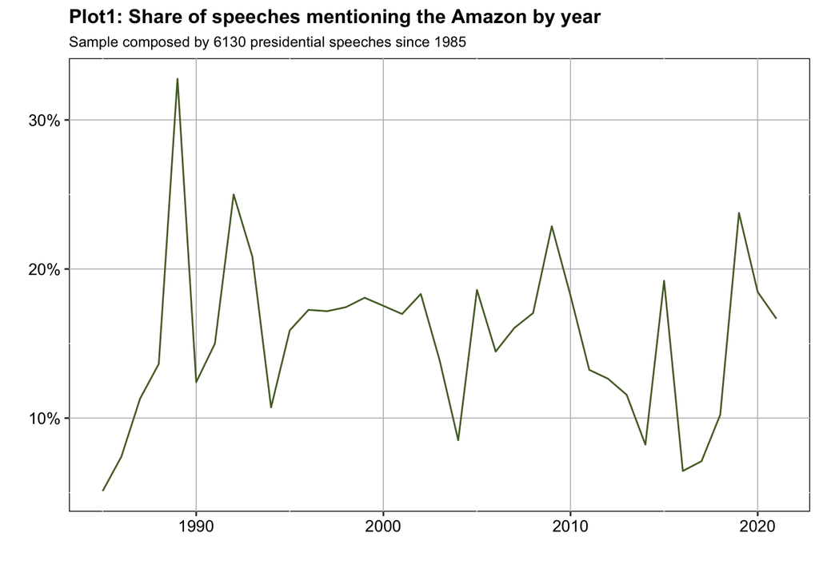

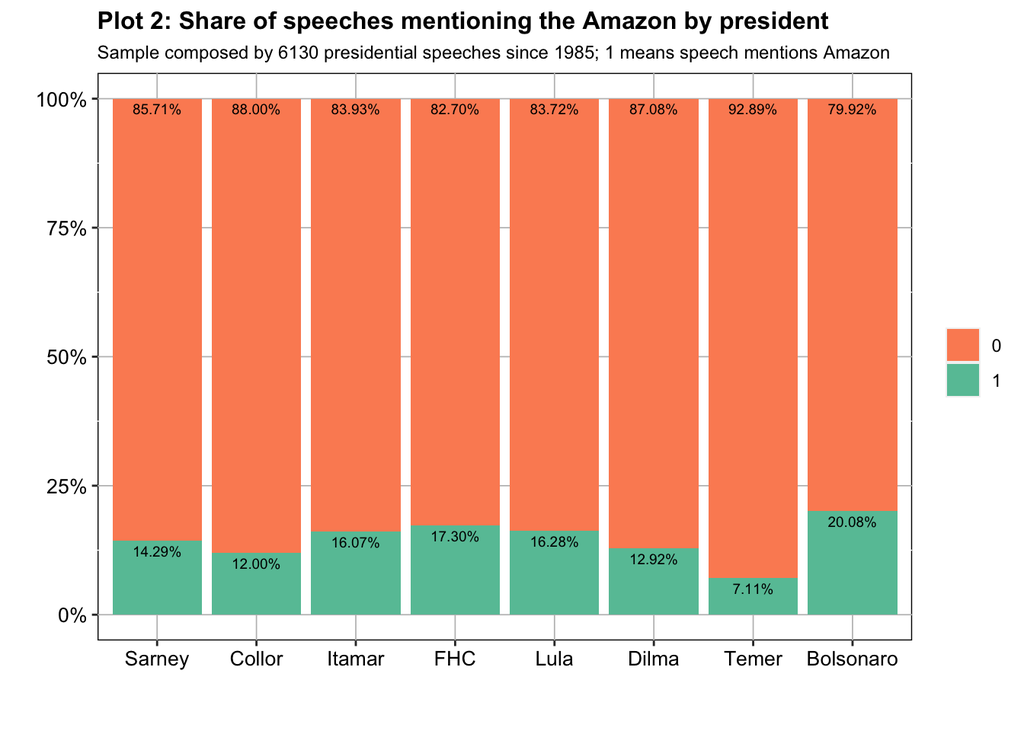

[figure not shown]

## II Incidence of problem construction in time

Question: do specific problem constructions get more salient over time?

Logic: compare yearly counts of problem construction in time;

Normalization: here I changed the unit of analysis from amazonian statements to problem construction, this means we have 2400 observations (see temp), I normalize by taking the proportion of each problem construction from yearly total.

Take on results: Plot 4 is more promising, there is some nice variation. Generally, the more salient problem-constructions are economic integration and conservation. While the former piked in the late 1998 (also when deforestation was high) and then started to decrease, the latter was more salient in the up-coming of the Earth Summit and remained fairly stable. Social development starts gaining more prominence with the PT government despite an unusually high year in 1992. Sovereignty, which remained fairly stable over time, is making a come-back in the late 2010, more prominently with the presidency of Jair Bolsonaro.

Given the results presented in the pure categories of the mixed-types section, it seems like we can basically subsume this analysis in the next section.

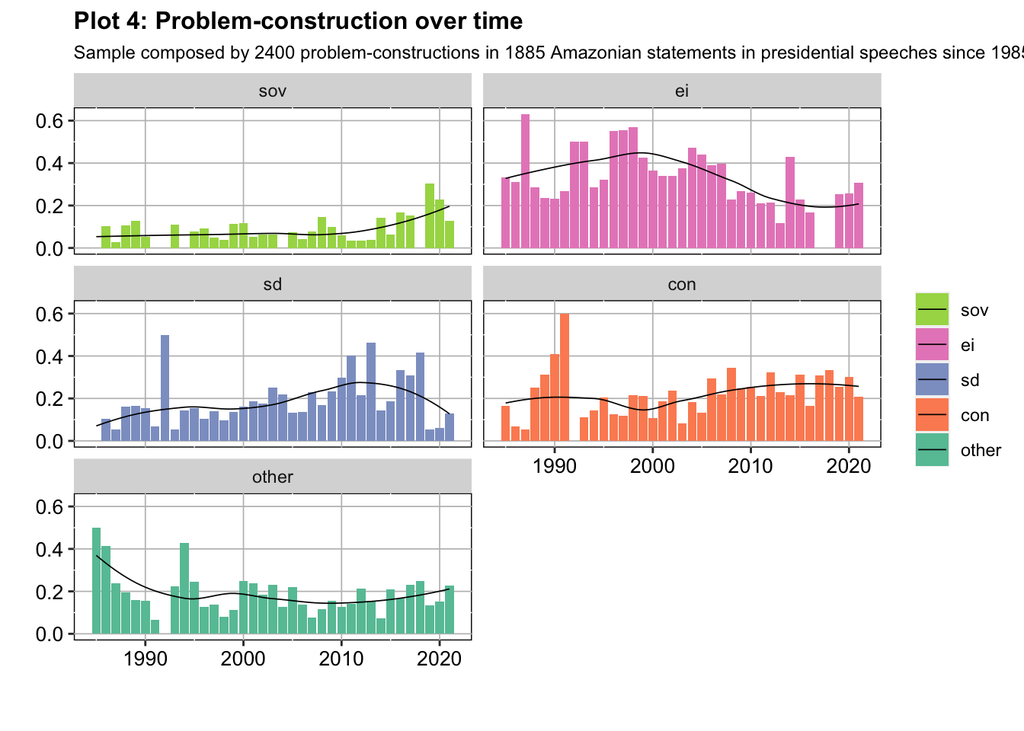

## III Mixed types: more complex problems?

Question: do specific combinations characterize specific presidents? Do we see the emergence of new combinations along time?

Logic: compare proportion of yearly mixed_types in time; here proportions add to 1 because the unit of analysis is each amazonian statement unique combination of our four main codes.

From exploration plot, I conceptualize the following categories, which are the most frequent out of the 16 distinct types identified in the data (stored as mx_cat):

1. pure-types: each one of 1000,0100,0010,0001 separately
2. other: 0000
3. Economic Conservation: 0101
4. Economic & Social Development:0110
5. Sovereign Conservation: 1001
6. Sovereign Integration: 1100
7. Sustainable Development:0111
8. other mixed_types: all other combinations

Normalization: proportions of mixed_types

First, pure-types dominate and presidents tend not to mix much. We are not looking at pure-types this way in the previous analysis since the unit changed. Lula and Bolsonaro, interestingly, are the ones that have the highest shares of mixes among their problem-construction.

I would make this a subsection of analysis, probably the last one, framing as the main “mixers” (they mix more than others) so we can speak only about bolsonaro versus lula.

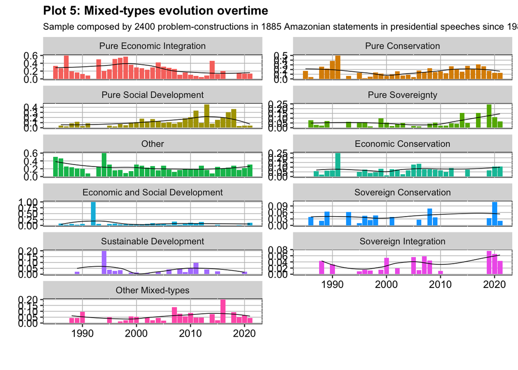

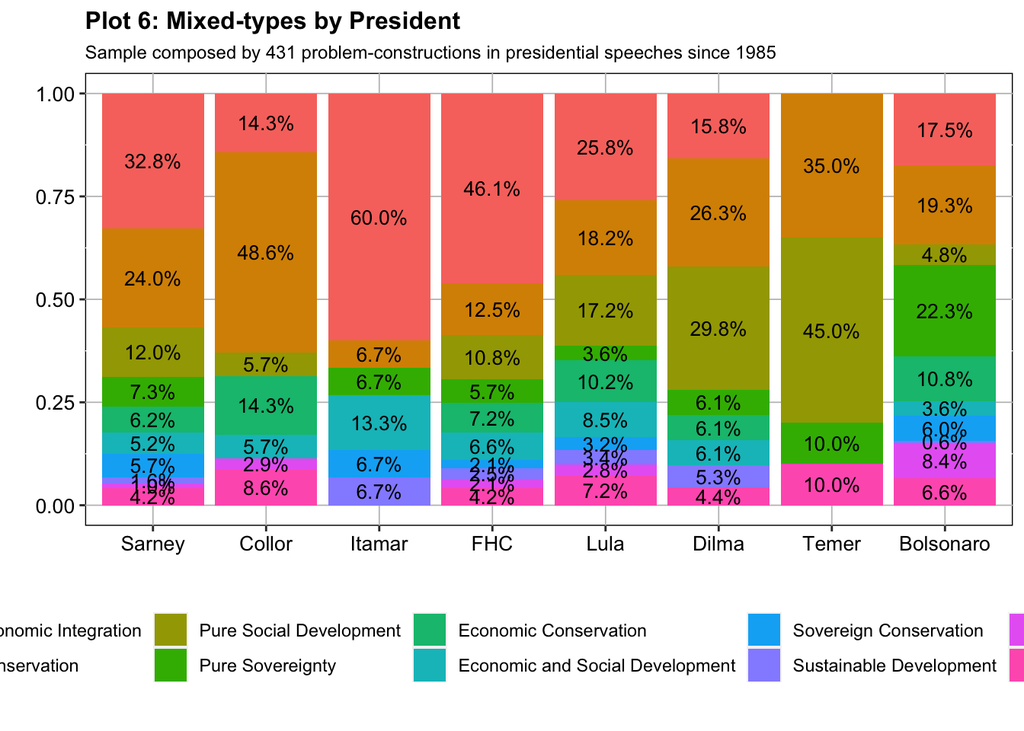

## IV Amazonian problem-construction in time, geographic location, and speaker

Question: do specific problem constructions differ by geographical location, speaker, and year?

Logic: see what better predicts problem constructions and mixed_types: location, speaker, year. This can be done with a multinominal logistic regression. We should add a few controls to this eventually (deforestation rates, gdp growth, approval rates, election year dummy, party affiliation/ideology), the problem is timing the variables properly.

take on results:

In theory model improvement might help us finding significant coefficients for the relationships we are interested at. I think the findings of m1 related to conservation are particularly interesting, we could keep them somehow.I suppose we can include something en passant in the second sub-section of analysis that looks into problem construction overtime ( II of this document), like Kentikellenis does.

### Model 1 w/ mx_cat as i.V.

i.Vs: mx_cat as i.V. for now it contains 11 levels, other is our base (unit of analysis remain each one of our 1885 Amazonian statements)

d.Vs: location_cat is to granular, for a more parsimonious model, I created two geographical dummies (amazon_state and Brazil)

```
## Call:
## multinom(formula = mx_cat ~ brazil + amazon_state, data = ama_mx)
##
## Coefficients:
##                                 (Intercept)   brazilYes amazon_stateYes
## Pure Economic Integration         0.4678774 -0.46312478     0.186306955
## Pure Conservation                 0.1001547 -0.36586739    -0.635653397
## Pure Social Development          -1.1525501  0.55901823     0.007245835
## Pure Sovereignty                 -1.7402294  0.65579830    -0.627882800
## Economic Conservation            -0.7471310 -0.48911461    -0.070583215
## Economic and Social Development  -1.2703583 -0.22661598     0.161956839
## Sovereign Conservation           -2.4333517  0.61258973    -0.990098446
## Sustainable Development          -2.4343953 -0.07936069     0.456573814
## Sovereign Integration            -2.2509481 -0.15173111     0.220383076
## Other Mixed-types                -1.2097630 -0.52644177     0.213163174
##
## Std. Errors:
##                                 (Intercept) brazilYes amazon_stateYes
## Pure Economic Integration         0.1689199 0.1950260       0.1524176
## Pure Conservation                 0.1828056 0.2106917       0.1923809
## Pure Social Development           0.2703644 0.2940741       0.1855128
## Pure Sovereignty                  0.3428231 0.3692886       0.2608306
## Economic Conservation             0.2336264 0.2752031       0.2375962
## Economic and Social Development   0.2829178 0.3257011       0.2492577
## Sovereign Conservation            0.4663748 0.5016766       0.4082729
## Sustainable Development           0.4665986 0.5303690       0.3604471
## Sovereign Integration             0.4291445 0.4914864       0.3627383
## Other Mixed-types                 0.2763474 0.3288725       0.2716438
##
## Residual Deviance: 7787.92
## AIC: 7847.92
```

```
##                                     (Intercept)  brazilYes amazon_stateYes
## Pure Economic Integration       0.0056087620844 0.01756405    0.2215771583
## Pure Conservation               0.5837773721434 0.08247440    0.0009526841
## Pure Social Development         0.0000201744804 0.05730942    0.9688438170
## Pure Sovereignty                0.0000003851133 0.07575895    0.0160734354
## Economic Conservation           0.0013839709228 0.07552124    0.7664114710
## Economic and Social Development 0.0000071155215 0.48656719    0.5158493701
## Sovereign Conservation          0.0000001812676 0.22205388    0.0153046049
## Sustainable Development         0.0000001815279 0.88105420    0.2052670270
## Sovereign Integration           0.0000001561144 0.75753542    0.5434833580
## Other Mixed-types               0.0000119943884 0.10943286    0.4326202253
```

```
##                                 (Intercept) brazilYes amazon_stateYes
## Pure Economic Integration        1.59660164 0.6293141       1.2047920
## Pure Conservation                1.10534191 0.6935948       0.5295893
## Pure Social Development          0.31583034 1.7489546       1.0072721
## Pure Sovereignty                 0.17548014 1.9266800       0.5337206
## Economic Conservation            0.47372372 0.6131690       0.9318502
## Economic and Social Development  0.28073103 0.7972269       1.1758095
## Sovereign Conservation           0.08774226 1.8452038       0.3715401
## Sustainable Development          0.08765073 0.9237067       1.5786559
## Sovereign Integration            0.10529934 0.8592193       1.2465542
## Other Mixed-types                0.29826795 0.5907031       1.2375866
```

### Model 2 w/ problem_construction as i.V.

i.Vs: problem_construction as i.V., contains 5 levels so more parsimonious model, other as base; here unit of analysis are instances of problem_construction (n=2400)

d.Vs: location_cat is to granular, for a more parsimonious model, I created two geographical dummies (amazon_state and Brazil)

```
## Call:
## multinom(formula = prob_constr ~ amazon_state + brazil, data = temp2)
##
## Coefficients:
##     (Intercept) amazon_stateYes   brazilYes
## con  0.69315521     -0.29830068 -0.33646489
## ei   0.96090258      0.17354998 -0.39719839
## sd  -0.07276068      0.09529125  0.07751611
## sov -0.67575859     -0.36108696  0.30544027
##
## Std. Errors:
##     (Intercept) amazon_stateYes brazilYes
## con   0.1622216       0.1506860 0.1855024
## ei    0.1557412       0.1363373 0.1781217
## sd    0.1908192       0.1543469 0.2142740
## sov   0.2280942       0.1865498 0.2523593
##
## Residual Deviance: 7328.189
## AIC: 7352.189
```

```
##     (Intercept) amazon_stateYes brazilYes
## con   2.0000161       0.7420782 0.7142910
## ei    2.6140548       1.1895201 0.6722007
## sd    0.9298233       1.0999792 1.0805996
## sov   0.5087703       0.6969184 1.3572224
```

```
##            (Intercept) amazon_stateYes  brazilYes
## con 0.0000192954451463      0.04774653 0.06970806
## ei  0.0000000006834777      0.20303722 0.02575229
## sd  0.7029755705485239      0.53698164 0.71753017
## sov 0.0030502370536365      0.05291591 0.22614892
```